# **Art rupestre** approches multi-paradigmes et multi-scalaires des graphies anciennes dans le contexte du Web3D et de la Science ouverte

Thomas Huet

Abstract

A web 3D multi-paradigm and multi-scalar presentation of ancient iconography (rock-art, hieroglyphs). 3D data management with open-source softwares (GitHub, 3DHOP, Blender, R, JavaScript, etc.) within the frame of Linked-Open data (LOD)

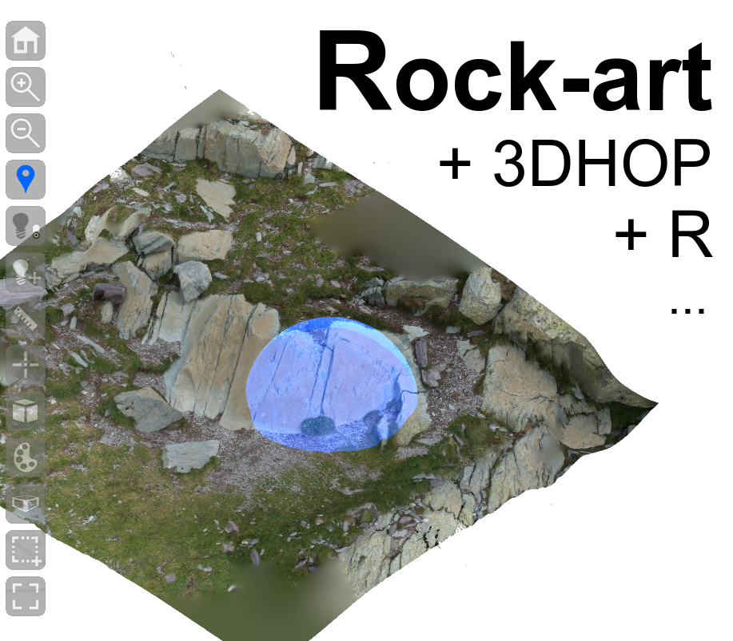

# Introduction

Nous présentons ci-dessous, un essai de FAIRisation des données liées aux graphies anciennes (art rupestre, hiéroglyphes) en nous focalisant sur la cartogaphie et la 3D. Ce document Rmarkdown (R + Markdown) alterne cartes, liens, tableaux, etc. avec des “morceaux de code” informatique (i.e. *code chunks*, en fond grisé). Les données qui ont servi sont enregistrées dans deux *repository* GitHub: zoometh/3DHOP qui est un *fork* de 3DHOP (*3D Heritage Online Presenter*), et où sont entreposés les données 3D, et zoometh/rockart pour le reste des données.

Ici, nous prenons ces deux (2) sites en exemple:

[interactive chart not shown]

Pour chacun de ces sites, le logo signale l’existence d’un modèle 3D

# Mont Bego

La région du mont Bégo (Alpes-Maritimes, France) est surtout connue pour son art rupestre avec un nombre impressionnant de roches gravées, mais le site est aussi l’un des premiers de montagne à être occupé au début du Néolithique (ca. -5300 BC)

## Données

Actuellement, les données sont stockées dans une base de données Postgres 13 locale. Ici, nous sélectionnons quelques champs - y compris les coordonnées géographiques - et les exportons dans un fichier `.csv` stocké dans le dépôt GitHub.

```r
drv <- dbDriver("PostgreSQL")
con <- dbConnect(RPostgres::Postgres(),
                 dbname = "bego_20_04_2021",
                 host="localhost",
                 port=5433,
                 user="postgres",
                 password="postgres")
sqll <- "SELECT idroche, nom, x, y, z FROM roches_spat"
roches.all <- dbGetQuery(con,sqll)
roches.all$idroche <- gsub("\\.", "\\_", roches.all$idroche )
write.csv(roches.all, "data/roches_all.csv", row.names = F)
dbDisconnect(con)
```

Certaines roches gravées ont été modélisées en 3D par photogrammétrie (logiciel commercial [Metashape Photoscan](https://www.agisoft.com/)) au format 3D (`.obj` ou `.ply`). Une application commerciale comme [Sketchfab](https://sketchfab.com) permet de mettre un modèle 3D en ligne et d’intégrer un conteneur `<iframe>` vers ce modèle. Comme ici:

[interactive chart not shown]

Dans le domaine du libre, ces modèles une fois transformés sont manipulés avec le [framework 3DHOP](http://www.3dhop.net/) et stockés dans le *fork* du dépôt GitHub [zoometh/3DHOP](https://github.com/zoometh/3DHOP/tree/master/minimal). Dans le `code chunk` ci-dessous, nous lisons le contenu du dossier ‘minimal’ pour obtenir les noms de ces modèles (stockés en tant que fichiers `.nxz` dans le dossier ‘models’).

```r
roches.all <- read.csv("data/roches_all.csv")
req <- GET(url.html)
stop_for_status(req)
filelist <- unlist(lapply(content(req)$tree, "[", "path"), use.names = F)
D3.models <- grep("minimal/.*html$", filelist, value = TRUE)
D3.models <- gsub("minimal/", "", D3.models)
D3.models <- sort(gsub(".html$", "", D3.models))
nm.models <- roches.all[roches.all$idroche %in% D3.models, "nom"]
l.nm.models <- paste0(paste0("*", nm.models, "* (", D3.models,")"))
nb.models <- length(D3.models)
```

Actuellement, il existe 6 modèles 3D: *Looped Skin Rock* (17_2_59@c), *Roche de l’archer* (18_1_28@a), *Roche de l’anthropomorphe aux bras en zigzag* (4_3_16D), *Stèle du Chef de Tribu* (7_1_8), *Roche du Sorcier* (8_2_34), *Looped Skin Rock* (KIU2610)

## Cartographie

Nous lions les URL des roches gravées modélisées en 3D par jointure sur leur identifiant (e.g., 7_1_8) dans la table des roches – pour les ouvrir directement à partir de la carte *Leaflet* –, et nous attribuons à ces roches une icône personnalisée ([icône ‘3DHOP’](https://raw.githubusercontent.com/zoometh/rockart/main/www/icon_3dhop.png))

```r
roches.3D <- roches.all[roches.all$idroche %in% D3.models, ]
roches.others <- roches.all[!(roches.all$idroche %in% D3.models), ]
roches.3D.icons <- icons(
  iconUrl = url.icon,
  iconWidth = 40, iconHeight = 56,
  iconAnchorX = 20, iconAnchorY = 28
)
roches.3D$desc <- paste0("roche: ", roches.3D$idroche, '<br> 3D model: <a href=',
                         shQuote(paste0(url.3dhop, roches.3D$idroche, ".html")),
                         "\ target=\"_blank\"",">", roches.3D$nom, "</a>")
roches.others$desc <- paste0("roche: ", roches.others$idroche)
leaflet(width = "700px", height = "700px") %>%
  addTiles(group = 'OSM') %>%
  addProviderTiles("Esri.WorldImagery", group = "Ortho") %>%
  addCircleMarkers(data = roches.others,
                   lng = ~x,
                   lat = ~y,
                   popup = ~desc,
                   color = "red",
                   radius = 0.5,
                   opacity = 0.8) %>%
  addMarkers(data = roches.3D,
             lng = ~x,
             lat = ~y,
             popup = ~desc,
             icon = roches.3D.icons) %>%
  addLayersControl(
    baseGroups = c('Ortho', 'OSM')) %>%
  addScaleBar(position = "bottomleft")
```

[interactive chart not shown]

Certains de ces modèles 3D ont des annotations, comme la *Roche de l’homme aux bras en zigzag*, ou la *Stèle du Chef de Tribu*

# Karnak

En Haute-Egypte, le complexe cultuel de Karnak (temples, pylos, chapelles, etc.) se développe au cours du Nouvel Empire, corrélativement au culte d’Amon. Le site est étudié depuis près de 150 ans par une équipe d’égyptologues français. La documentation de ces monuments en 3D, et l’interopérabilité de ces modèles 3D, peut permettre de mieux comprendre l’évolution des hiéroglyphes dans le temps (paléographie)

## Données

Le jeu de données correspond à un fichier .csv (locus.csv) conservé sur GitHub

```r
locus <- read.csv("www/locus.csv", sep = ";", row.names = NULL)
kable(locus, "html", escape = FALSE,
      caption = "Données Karnak") %>%
  kable_styling(bootstrap_options = c("hover", "condensed"), font_size=12)
```

Données Karnak

| KIU | nom | couleur | D3 | X | Y | credit3D |
| --- | --- | --- | --- | --- | --- | --- |
| 1027 | Chapelle de Sésostris Ier | white | NA | 32.65720 | 25.72034 |  |
| 1192 | Chapelle d’Hatshepsut | red | NA | 32.65768 | 25.72043 |  |
| 2610 | Chapelle de Philippe Arrhidée | green | KIU2610 | 32.65867 | 25.71810 | SirCharlesWilson - Sketchfab |

Les liens entre ces données et leurs identifiants [KIU (*Karnak Identifiant Unique*)](http://sith.huma-num.fr/karnak/) – qui sont égalment des URL– sont générés par concatenation

```r
url.sith <- "http://sith.huma-num.fr/karnak/"
locus$url <- paste0('<a href=', shQuote(paste0(url.sith, locus$KIU)),
                    "\ target=\"_blank\"",">", paste0("KIU",locus$KIU), "</a>")
```

Le (très beau) modèle 3D de KIU2610, nous est fourni par [Sketchfab](https://sketchfab.com/3d-models/karnak-holy-of-holies-south-exterior-77e3e1eba8cc49fe8c04d6b3343b9dc4)

[interactive chart not shown]

Ce modèle est ouvert dans Blender et une nouvelle géométrie (un mesh) sur une partie de sa surface pour signaler un panneau (KIU2613). Ce panneau est donc un sous-ensemble de KIU2160

## Cartographie

Ces données sont comparées avec les modèles 3D existant dans le repository GitHub [zoometh/3DHOP](https://github.com/zoometh/3DHOP/tree/master/minimal)

```r
req <- GET(url.html)
stop_for_status(req)
filelist <- unlist(lapply(content(req)$tree, "[", "path"), use.names = F)
D3.models <- grep("minimal/.*html$", filelist, value = TRUE)
D3.models <- gsub("minimal/", "", D3.models)
D3.models <- sort(gsub(".html$", "", D3.models))
nm.models <- locus[locus$url %in% D3.models, "D3"]
nb.models <- length(nrow(nm.models))

monum.3D <- locus[locus$D3 %in% D3.models, ]
monum.others <- locus[!(locus$D3 %in% D3.models), ]
monum.3D.icons <- icons(
  iconUrl = url.icon,
  iconWidth = 40, iconHeight = 56,
  iconAnchorX = 0, iconAnchorY = 0
)
monum.3D$desc <- paste0(monum.3D$url, " : ", monum.3D$nom, '<br><a href=',
                        shQuote(paste0(url.3dhop, monum.3D$D3, ".html")),
                        "\ target=\"_blank\"",">","<b> modèle 3D </b>", "</a>")
monum.others$desc <- paste0(monum.others$url, " : ", monum.others$nom)
leaflet(width = "700px", height = "700px") %>%
  addTiles(group = 'OSM') %>%
  addProviderTiles("Esri.WorldImagery", group = "Ortho") %>%
  addCircleMarkers(data = monum.others,
                   lng = ~X,
                   lat = ~Y,
                   popup = ~desc,
                   color = ~couleur,
                   radius = 15,
                   opacity = .5) %>%
  addMarkers(data = monum.3D,
             lng = ~X,
             lat = ~Y,
             popup = ~desc,
             icon = monum.3D.icons) %>%
  addLayersControl(
    baseGroups = c('Ortho', 'OSM')) %>%
  addScaleBar(position = "bottomleft")
```

[interactive chart not shown]